# Excess Bereavement and Excess Mortality: Some Analysis

In this document, I outline the process for analyzing the data derived from the analysis scripts and generating the quantities we need for the regression.

```r
#Loading dependencies
require(tidyverse)
require(data.table)
require(countrycode) #For labeling graphs
require(stargazer)
source("~/covid_simulation/Kin_death/01_load_functions.R")
```

```
## [1] "library2: tidyverse loaded."
## [1] "library2: scales loaded."
## [1] "library2: patchwork loaded."
## [1] "library2: data.table loaded."
## [1] "library2: parallel loaded."
## [1] "library2: knitr loaded."
```

```r
source('~/covid_simulation/Kin_death/functions_bereavement.R')
```

First, load the data.

```r
data <- get(load(file = "../Data/final_data_preprint.RData"))
remove(data_preprint)
```

## Independent Variables

### Excess Mortality

We can calculate these quantities as follows:

```r
#Match Covid and counterfactual simulations, and clean data
death_rates <- data$death_rates %>%
  filter(!is.na(scenario)) %>%
  mutate(sex = ifelse(fem == 1, "F", "M")) %>%
  ungroup() %>%
  group_by(country, scenario, sex, age) %>%
  mutate(index = row_number(), fem = NULL) %>%
  filter(index <= 99) %>% #Temporary solution for addressing matching issue
  ungroup() %>%
  pivot_wider(id_cols = c("country", "sex", "age", "index"),
              names_from = "scenario",
              values_from = c("n_num", "n_den", "value", "sim.id"))
```

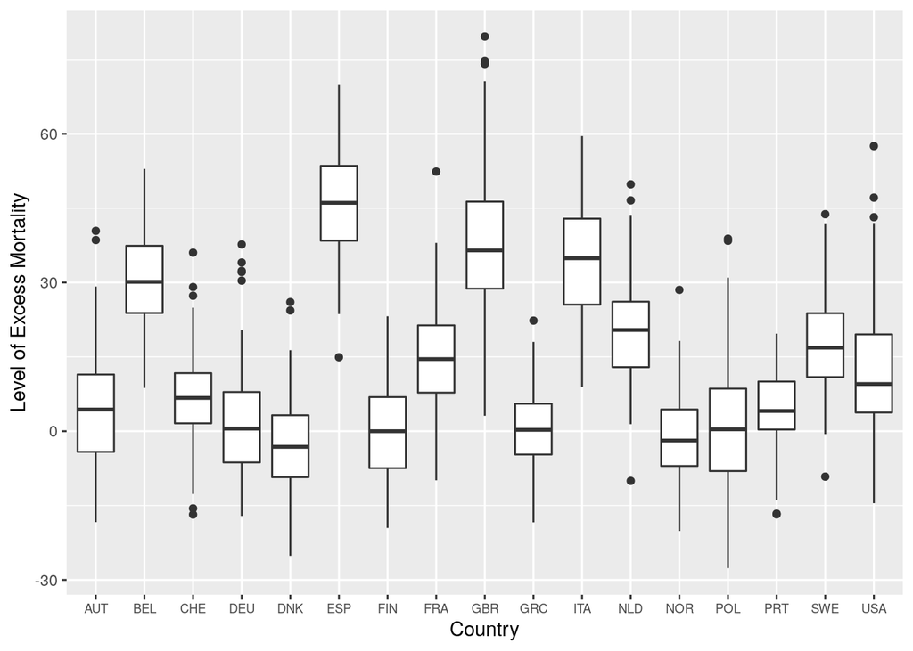

```r
#Excess mortality level
em_level <- death_rates %>%
  filter(age %in% c("15-29", "30-44", "45-64", "65+")) %>%
  ungroup() %>%
  group_by(country, index, sim.id_covid, sim.id_other) %>%
  summarize(deaths_covid = sum(n_num_covid, na.rm = T),
            deaths_other = sum(n_num_other, na.rm = T)) %>%
  mutate(em_level = 100*(deaths_covid - deaths_other)/(deaths_other),
         ccode = countrycode(gsub("_", " ", country),
                             origin = 'country.name', destination = 'iso3c'))

#Get the distribution of this by country and plot it
em_level %>%
  ggplot() + geom_boxplot(aes(x = ccode, y = em_level)) +
  labs(x = "Country", y = "Level of Excess Mortality") +
  theme(axis.text.x = element_text(size = 7))
```

```r
#Summarize it
em_level %>%
  ungroup() %>%
  group_by(country) %>%

  summarize(mean_em_level = mean(em_level, na.rm = T))
```

```
## # A tibble: 17 x 2
##    country                  mean_em_level
##    <chr>                            <dbl>
##  1 Austria                          5.15
##  2 Belgium                         31.4
##  3 Denmark                         -2.65
##  4 Finland                          0.257
##  5 France                          15.1
##  6 Germany                          1.49
##  7 Greece                           0.681
##  8 Italy                           34.6
##  9 Netherlands                     20.2
## 10 Norway                          -1.08
## 11 Poland                           1.42
## 12 Portugal                         4.85
## 13 Spain                           45.9
## 14 Sweden                          17.5
## 15 Switzerland                      6.98
## 16 United_Kingdom                  37.7
## 17 United_States_of_America        11.5
```

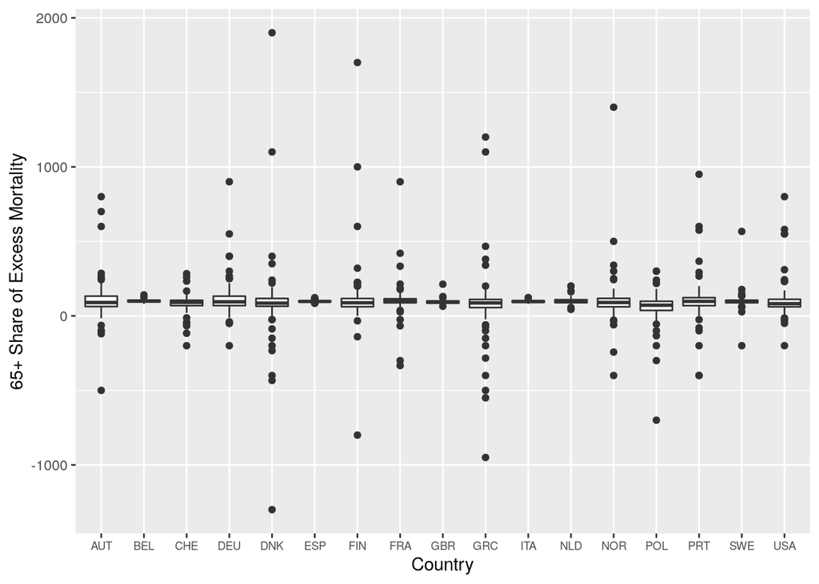

```r
#Age ratio of excess mortality
em_age <- death_rates %>%
  filter(age %in% c("15-29", "30-44", "45-64", "65+")) %>%
  mutate(above65 = if_else(age %in% c("65+"), "65plus", "below65")) %>%
  ungroup() %>%
  group_by(country, index, sim.id_covid, sim.id_other, above65) %>%
  summarize(deaths_covid = sum(n_num_covid, na.rm = T),
            deaths_other = sum(n_num_other, na.rm = T)) %>%
  pivot_wider(names_from = "above65", values_from = c("deaths_covid", "deaths_other")) %>%
  mutate(em_share_age = 100*(deaths_covid_65plus - deaths_other_65plus)/(deaths_covid_below65+deaths_covid_65plus - deaths_other_below65 - deaths_other_65plus),
         ccode = countrycode(gsub("_", " ", country),
                             origin = 'country.name', destination = 'iso3c'))

#Graph this
em_age %>%
  ggplot() + geom_boxplot(aes(x = ccode, y = em_share_age)) +
  labs(x = "Country", y = "65+ Share of Excess Mortality") +
  theme(axis.text.x = element_text(size = 7))
```

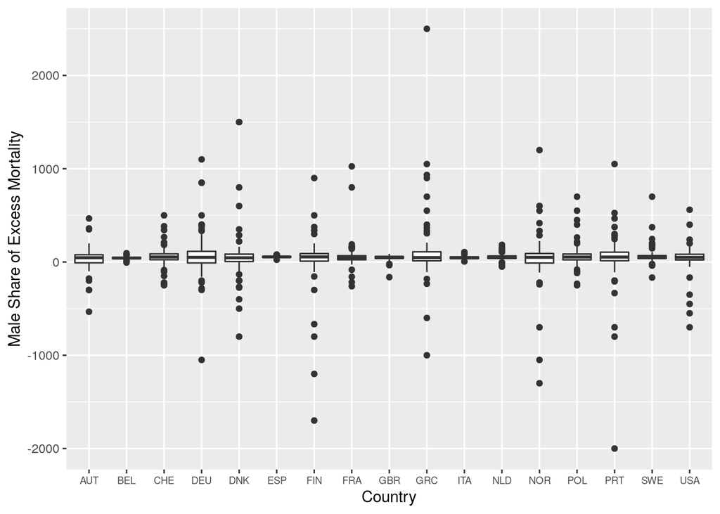

```r
#Sex ratio of excess mortality
em_sexratio <- death_rates %>%
  filter(age %in% c("15-29", "30-44", "45-64", "65+")) %>%
  ungroup() %>%
  group_by(country, index, sim.id_covid, sim.id_other, sex) %>%
  summarize(deaths_covid = sum(n_num_covid, na.rm = T),
            deaths_other = sum(n_num_other, na.rm = T)) %>%
  pivot_wider(names_from = "sex", values_from = c("deaths_covid", "deaths_other")) %>%
  mutate(em_sexratio = 100*(deaths_covid_M - deaths_other_M)/(deaths_covid_F + deaths_covid_M - deaths_other_F - deaths_other_M),
         ccode = countrycode(gsub("_", " ", country),
                             origin = 'country.name', destination = 'iso3c'))

#Graph this
em_sexratio %>%
  ggplot() + geom_boxplot(aes(x = ccode, y = em_sexratio)) +
  labs(x = "Country", y = "Male Share of Excess Mortality") +
  theme(axis.text.x = element_text(size = 7))
```

QUESTION: We see a lot of fluctuation in the age ratio and sex ratio measures for excess mortality, because the numbers are quite low and in some cases the number of excess deaths will be in fact negative. Do you have any thoughts on whether this is an issue? Should we be defining these quantities differently?

### Population Structure

We can calculate these quantities from the death rates object as well, using population exposures. One thing to note is that for each pair of simulations, we have two sets of exposures. Here, I simply average over the two cases, as this is pre-Covid-19 and unlikely to affect the results.

I use the same death_rates object from previously to calculate these quantities.

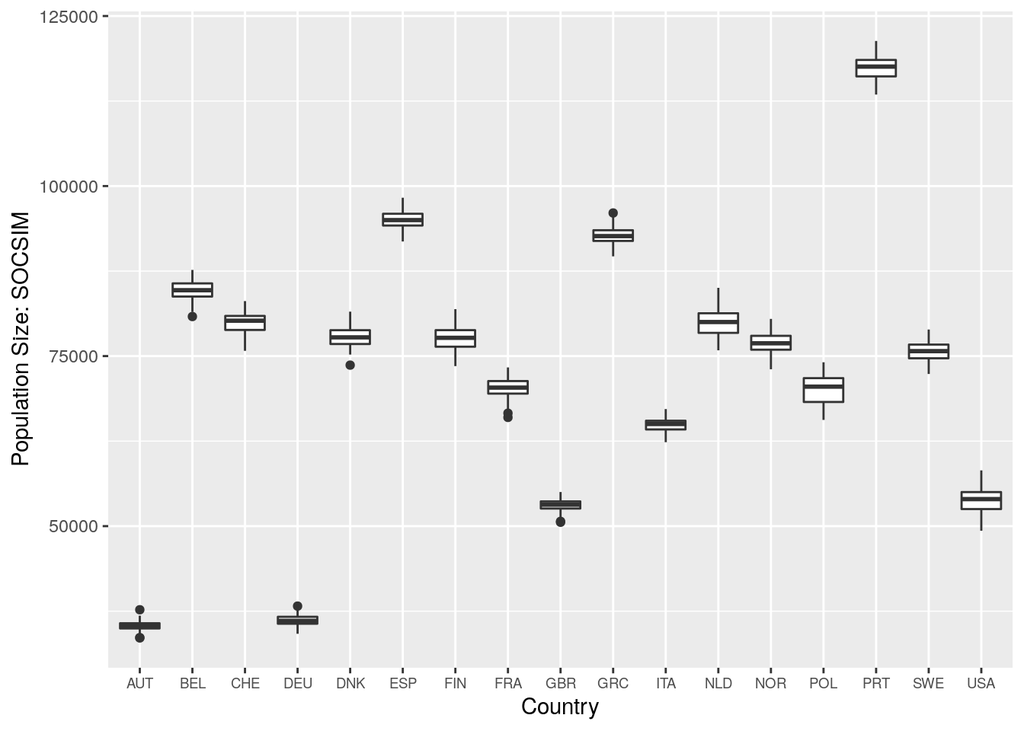

```r
#Calculating size of population
pop_size <- death_rates %>%
  filter(age == "all_sum") %>% #This previously summed up population exposures
  mutate(pop_size = (n_den_covid+n_den_other)/2) %>%
  select(c(country, index, sim.id_covid, sim.id_other, pop_size))

#Graph these results
pop_size %>%
 mutate(ccode = countrycode(gsub("_", " ", country),
                             origin = 'country.name', destination = 'iso3c')) %>%
  ggplot() + geom_boxplot(aes(x = ccode, y = pop_size)) +
  labs(x = "Country", y = "Population Size: SOCSIM") +
  theme(axis.text.x = element_text(size = 7))
```

```r
#Plot UNWPP populations by country
countrylist <- death_rates %>%
  mutate(ccode = countrycode(gsub("_", " ", country),
                             origin = 'country.name', destination = 'iso3c')) %>%
  pull(ccode)

countrylist <- unique(countrylist)

#Load UNWPP data
unwpp_data <- fread("https://population.un.org/wpp/Download/Files/1_Indicators%20(Standard)/CSV_FILES/WPP2019_TotalPopulationBySex.csv")
```

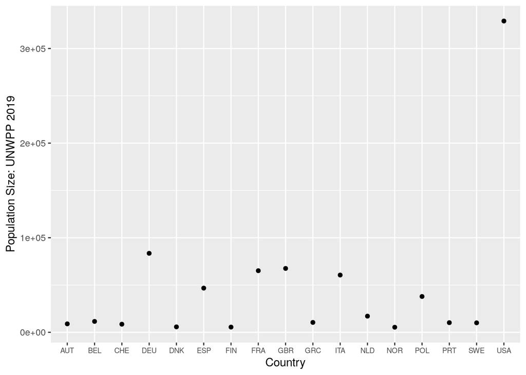

```r
#Modify and filter data
unwpp_pop <- unwpp_data %>%
  filter(Time == 2019 & Variant == "Medium") %>%
  mutate(ccode = countrycode(Location, origin = 'country.name', destination = 'iso3c'),
           unwpp_pop = PopTotal) %>%
  filter(ccode %in% countrylist & Location %in% grep(pattern = "dependencies", x = Location, invert = T, value = T)) %>%
  select(ccode, unwpp_pop)

unwpp_pop %>%
  ggplot() + geom_point(aes(x = ccode, y = unwpp_pop)) +
  labs(x = "Country", y = "Population Size: UNWPP 2019") +
  theme(axis.text.x = element_text(size = 7))
```

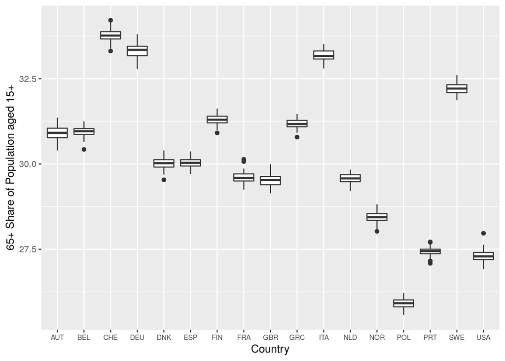

```r
#Calculate above-15 age ratios
pop_ageratio <- death_rates %>%
  filter(age %in% c("15-29", "30-44", "45-64", "65+")) %>%
  mutate(above65 = if_else(age %in% c("65+"), "65plus", "below65")) %>%
  ungroup() %>%
  group_by(country, index, sim.id_covid, sim.id_other, above65) %>%
  summarize(pop_covid = sum(n_den_covid, na.rm = T),
            pop_other = sum(n_den_other, na.rm = T)) %>%
  mutate(pop_total = (pop_covid + pop_other)/2) %>%
  select(-c(pop_covid, pop_other)) %>%
  pivot_wider(names_from = "above65", names_prefix = "pop", values_from = "pop_total") %>%
  mutate(pop_ageratio = 100*(pop65plus/(pop65plus + popbelow65))) %>%
  select(-c(pop65plus, popbelow65))


#Graph these by country
pop_ageratio %>%
 mutate(ccode = countrycode(gsub("_", " ", country),
                             origin = 'country.name', destination = 'iso3c')) %>%
  ggplot() + geom_boxplot(aes(x = ccode, y = pop_ageratio)) +
  labs(x = "Country", y = "65+ Share of Population aged 15+") +
  theme(axis.text.x = element_text(size = 7))
```

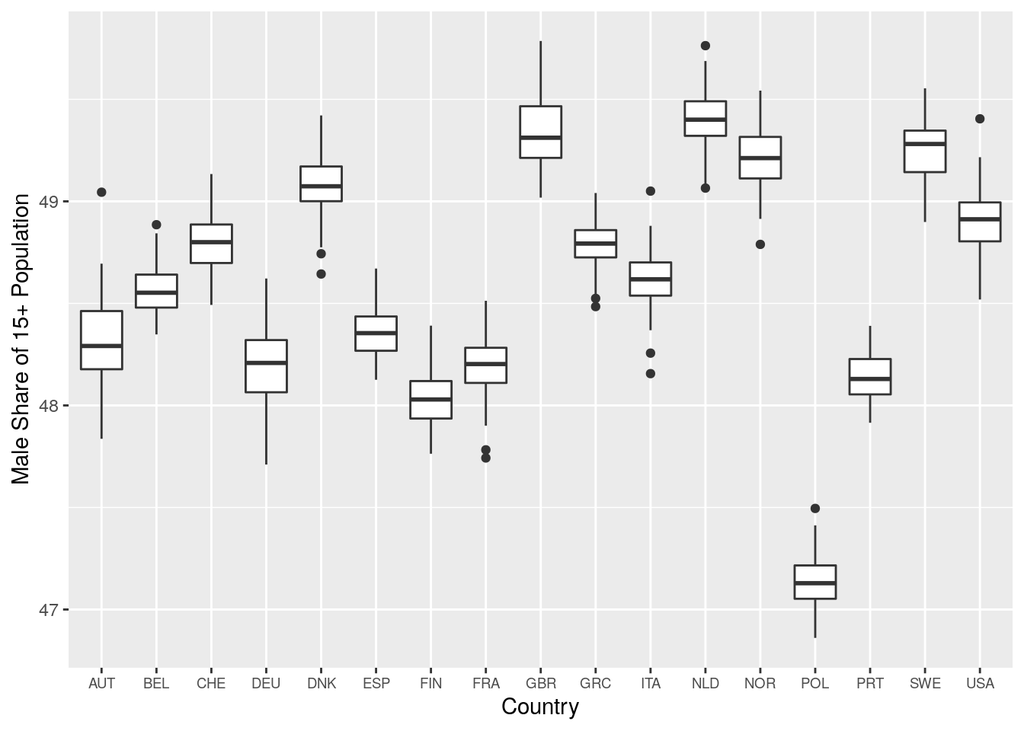

```r
#Calculate above-15 sex ratio
pop_sexratio <- death_rates %>%
  filter(age %in% c("15-29", "30-44", "45-64", "65+")) %>%
  ungroup() %>%
  group_by(country, index, sim.id_covid, sim.id_other, sex) %>%
  summarize(pop_covid = sum(n_den_covid, na.rm = T),
            pop_other = sum(n_den_other, na.rm = T)) %>%
  mutate(pop_total = (pop_covid + pop_other)/2) %>%
  select(-c(pop_covid, pop_other)) %>%
  pivot_wider(names_from = "sex", names_prefix = "pop", values_from = "pop_total") %>%
  mutate(pop_sexratio = 100*(popM/(popF+popM)),
         ccode = countrycode(gsub("_", " ", country),
                             origin = 'country.name', destination = 'iso3c')) %>%
  select(-c(popM, popF))


#Graph these by country
pop_sexratio %>%
  ggplot() + geom_boxplot(aes(x = ccode, y = pop_sexratio)) +
  labs(x = "Country", y = "Male Share of 15+ Population") +
  theme(axis.text.x = element_text(size = 7))
```

### Kinship Structure

We calculate this using the kin_ratio object.

```r
#Match Covid and counterfactual simulations, and clean data
kin_ratio <- data$kin_ratio %>%
  filter(!is.na(scenario)) %>%
  mutate(sex = ifelse(grepl("f1", category), "F", "M"),
  age = gsub("f[0-1]{1}", "", category),
  category = NULL) %>%
  ungroup() %>%
  filter(kintype == "nuclear") %>%
  complete(age, nesting(country, scenario, sim.id, sex, kintype)) %>%
  group_by(country, scenario, sex, age) %>%
  mutate(index = row_number()) %>%
  filter(index <= 99) %>% #Temporary solution for addressing matching issue
  ungroup() %>%
  pivot_wider(id_cols = c("country", "sex", "age", "index"),
              names_from = "scenario",
              values_from = c("count_all", "count_female", "count_male", "count_65plus", "count_below65", "n_egos", "sim.id"))
```

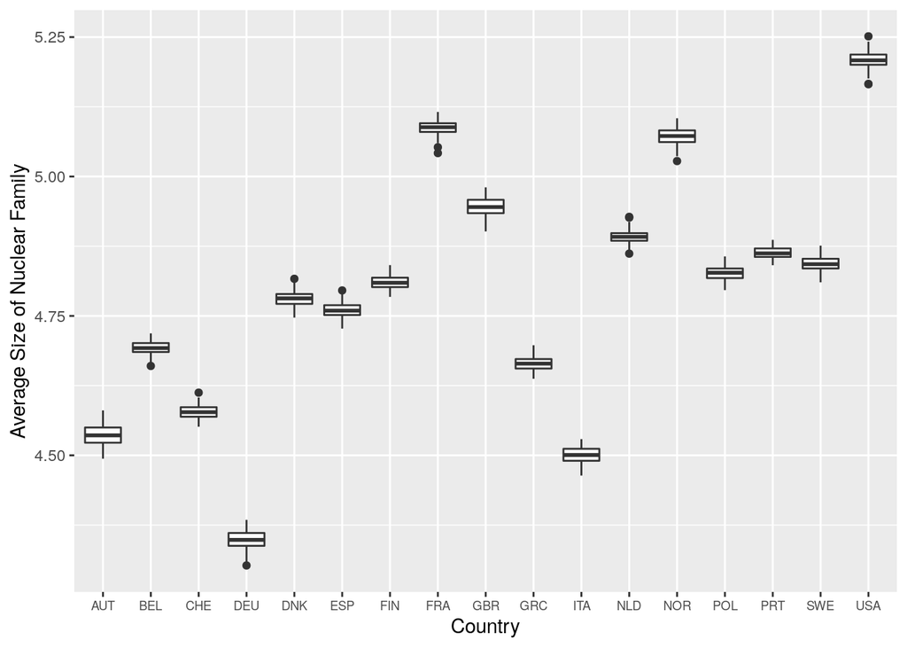

```r
#Size of family
kin_size <- kin_ratio %>%
  mutate(count_all_ages_covid = count_all_covid*n_egos_covid,
         count_all_ages_other = count_all_other*n_egos_other) %>% group_by(country, index, sim.id_covid, sim.id_other) %>%
  summarize(n_egos_covid = sum(n_egos_covid, na.rm = T),
            n_egos_other = sum(n_egos_other, na.rm = T),
            n_kin_covid = sum(count_all_ages_covid, na.rm=T)/n_egos_covid,
            n_kin_other = sum(count_all_ages_other, na.rm =T)/n_egos_other) %>%
  mutate(kin_size = (n_kin_covid + n_kin_other)/2,
         ccode = countrycode(gsub("_", " ", country),
                             origin = 'country.name', destination = 'iso3c')) %>%
  select(country, ccode, index, sim.id_covid, sim.id_other, kin_size)

#Graph this
kin_size %>%
  ggplot() + geom_boxplot(aes(x = ccode, y = kin_size)) +
  labs(x = "Country", y = "Average Size of Nuclear Family") +
  theme(axis.text.x = element_text(size = 7))
```

```r
#Age ratio for kin
kin_ageratio <- kin_ratio %>%
  mutate(count_65plus_covid = count_65plus_covid*n_egos_covid,
         count_65plus_other = count_65plus_other*n_egos_other,
         count_below65_covid = count_below65_covid*n_egos_covid,
         count_below65_other= count_below65_other*n_egos_other) %>%
  ungroup() %>%
  group_by(country, index, sim.id_covid, sim.id_other) %>%
  summarize(n_egos_covid = sum(n_egos_covid, na.rm = T),
            n_egos_other = sum(n_egos_other, na.rm = T),
            n_kin_65plus_covid = sum(count_65plus_covid, na.rm=T)/n_egos_covid,
            n_kin_65plus_other = sum(count_65plus_other, na.rm=T)/n_egos_other,
            n_kin_below65_covid = sum(count_below65_covid, na.rm=T)/n_egos_covid,
            n_kin_below65_other = sum(count_below65_other, na.rm=T)/n_egos_other) %>%
  mutate(kin_65plus = (n_kin_65plus_covid + n_kin_65plus_other)/2,
         kin_below65 = (n_kin_below65_covid + n_kin_below65_other)/2,
         kin_ageratio = 100*(kin_65plus/(kin_below65 + kin_65plus)),
         ccode = countrycode(gsub("_", " ", country),
                             origin = 'country.name', destination = 'iso3c')) %>%
  select(country, ccode, index, sim.id_covid, sim.id_other, kin_ageratio)

#Graph this
kin_ageratio %>%
  ggplot() + geom_boxplot(aes(x = ccode, y = kin_ageratio)) +
  labs(x = "Country", y = "Share of Extended Kin Aged 65+") +
  theme(axis.text.x = element_text(size = 7))
```

[output not shown]

```r
#Sex ratio for kin
kin_sexratio <- kin_ratio %>%
  mutate(count_female_covid = count_female_covid*n_egos_covid,
         count_female_other = count_female_other*n_egos_other,
         count_male_covid = count_male_covid*n_egos_covid,
         count_male_other= count_male_other*n_egos_other) %>%
  ungroup() %>%
  group_by(country, index, sim.id_covid, sim.id_other) %>%
  summarize(n_egos_covid = sum(n_egos_covid, na.rm = T),
            n_egos_other = sum(n_egos_other, na.rm = T),
            n_kin_female_covid = sum(count_female_covid, na.rm=T)/n_egos_covid,
            n_kin_female_other = sum(count_female_other, na.rm=T)/n_egos_other,
            n_kin_male_covid = sum(count_male_covid, na.rm=T)/n_egos_covid,
            n_kin_male_other = sum(count_male_other, na.rm=T)/n_egos_other) %>%
  mutate(kin_female = (n_kin_female_covid + n_kin_female_other)/2,
         kin_male = (n_kin_male_covid + n_kin_male_other)/2,
         kin_sexratio = 100*(kin_male/(kin_female + kin_male)),
         ccode = countrycode(gsub("_", " ", country),
                             origin = 'country.name', destination = 'iso3c')) %>%
  select(country, ccode, index, sim.id_covid, sim.id_other, kin_sexratio)

#Graph this
kin_sexratio %>%
  ggplot() + geom_boxplot(aes(x = ccode, y = kin_sexratio)) +
  labs(x = "Country", y = "Male Share of Extended Kin") +
  theme(axis.text.x = element_text(size = 7))
```

[output not shown]

## Dependent Variable: Excess Bereavement

There are different ways of calculating excess bereavement. Here, we use a relative difference consistent with what we did for excess mortality. One definition that seems fairly consistent with excess mortality is to look at bereavement across the two different scenarios, where bereavement is measured as the difference in mean kin counts for individuals with at least one kin member of a certain type at the start of the period. Here, I define the excess bereavement, where K represents the average number of kin surviving for an ego with at least one relative alive at the start of the period, as follows:

$$EBR = \frac{(K_{pre,Covid} - K_{post, Covid}) - (K_{pre,Counterfactual} - K_{post, Counterfactual})}{(K_{pre,Counterfactual} - K_{post, Counterfactual}) }$$
One thing we talked about a bit in some of the early work around the paper was the probability of losing a type of relative; I don’t think that’s what we’re really measuring here, so we may need some alternative analysis to get at that. QUESTION: Am I remembering our discussion on this quantity correctly?

I load the kin_bb object, which is used for calculating excess bereavement. One big question is what level we want this data to be at. For now I have these numbers calculated individually for each age-sex category and kin type for each simulation (which will facilitate regression analysis later by either ego characteristics/type of kin). Later for the table, though, I think I will need to aggregate across age categories to address all the NA values.

```r
#Calculate excess bereavement rates
kin_ebr <-data$kin_bb %>%
  filter(!is.na(scenario)) %>%
  mutate(sex = ifelse(grepl("f1", category), "F", "M"),
    age = gsub("f[0-1]{1}", "", category),
    category = NULL) %>%
  ungroup() %>%
  complete(age, nesting(country, scenario, sim.id, sex, kintype)) %>%
  group_by(country, scenario, sex, age, kintype) %>%
  mutate(index = row_number(), category = NULL) %>%
  filter(index <= 99) %>% #Temporary solution for addressing matching issue
  ungroup() %>%
  pivot_wider(id_cols = c("country", "sex", "age", "kintype", "index"),
              names_from = "scenario",
              values_from = c("mean_pre_with", "sd_pre_with", "n_withkin",
                              "mean_post_with", "sd_post_with", "sim.id", "n_losekin", "n_total")) %>%
  mutate(bereavement_covid = (mean_pre_with_covid - mean_post_with_covid),
         bereavement_other = (mean_pre_with_other - mean_post_with_other),
         n_withkin = (n_withkin_covid + n_withkin_other)/2,
         ebr = 100*(bereavement_covid)/(bereavement_other),
         ccode = countrycode(gsub("_", " ", country),
                             origin = 'country.name', destination = 'iso3c'))
```

Here, I create an aggregated version of this dataset, aggregating across age and sex by kin type and simulation. This is useful because otherwise we have a large number of NA values (eg. no children for 0-14, etc.). This creates issues with the regression, and also prevents kin losses from being weighted appropriately by the number of egos actually in a category.

```r
kin_ebr_kintype <- kin_ebr %>%
  ungroup %>%
  mutate(sum_kin_loss_covid = bereavement_covid*n_withkin,
         sum_kin_loss_other = bereavement_other*n_withkin) %>%
  group_by(country, ccode, sim.id_covid, sim.id_other, kintype) %>%
  summarize(sum_bereavement_covid = sum(sum_kin_loss_covid, na.rm = T),
            sum_bereavement_other = sum(sum_kin_loss_other, na.rm = T),
            n_total = sum(n_withkin, na.rm = T),
            mean_bereavement_covid = sum_bereavement_covid/n_total,
            mean_bereavement_other = sum_bereavement_other/n_total) %>%
  mutate(ebr = 100*(mean_bereavement_covid - mean_bereavement_other)/mean_bereavement_other)
```

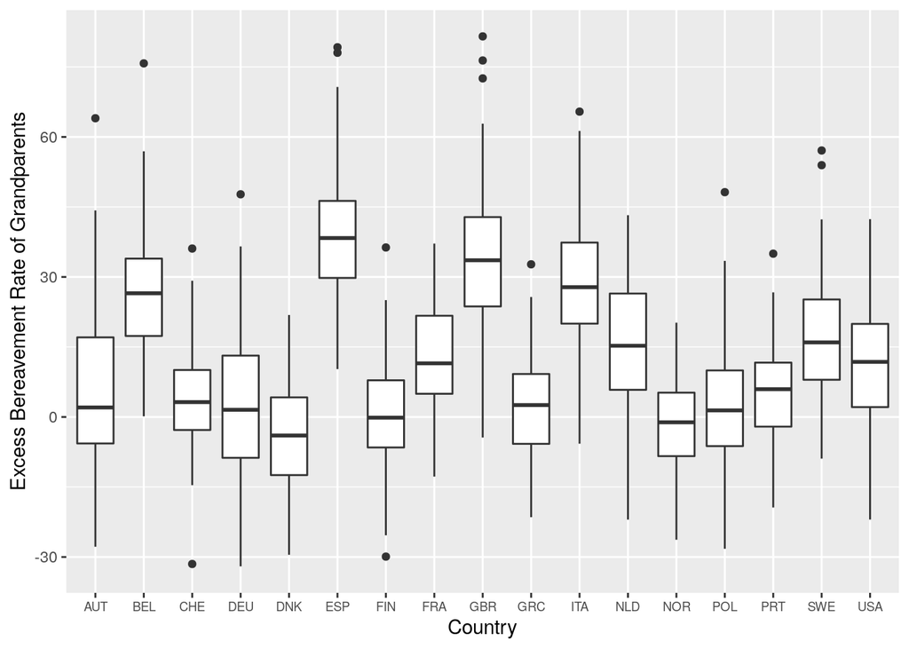

```r
#Graph an example
kin_ebr_kintype %>%
  filter(kintype == "gparents") %>%
  ggplot() + geom_boxplot(aes(x = ccode, y = ebr)) +
  labs(x = "Country", y = "Excess Bereavement Rate of Grandparents") +
  theme(axis.text.x = element_text(size = 7))
```

```r
kin_ebr_kintype %>%
  filter(kintype == "gparents") %>%
  ungroup() %>%
  group_by(country) %>%
  summarize(mean_ebr = mean(ebr, na.rm = T))
```

```
## # A tibble: 17 x 2
##    country                  mean_ebr
##    <chr>                       <dbl>
##  1 Austria                     5.47
##  2 Belgium                    25.9
##  3 Denmark                    -4.01
##  4 Finland                     0.933
##  5 France                     12.6
##  6 Germany                     2.02
##  7 Greece                      2.14
##  8 Italy                      28.1
##  9 Netherlands                16.0
## 10 Norway                     -1.69
## 11 Poland                      2.85
## 12 Portugal                    5.35
## 13 Spain                      39.4
## 14 Sweden                     17.4
## 15 Switzerland                 4.03
## 16 United_Kingdom             34.0
## 17 United_States_of_America   11.4
```

## Preparing the Dataset for Regression Analysis

Now, we can combine the various objects generated previously to create a dataset used in our regression analysis.

```r
#Merge data objects by category
em_data <- merge(em_sexratio, merge(em_level, em_age))
pop_data <- merge(unwpp_pop, merge(pop_sexratio, pop_ageratio))
#kin_data <- merge(kin_sexratio, merge(kin_size, kin_ageratio))
kin_data <- kin_size
```

```r
#And get a tibble of covariates
covariates <- merge(kin_data, merge(pop_data, em_data))
```

```r
#Now merge with the dependent variable
tabledata_kintype <- merge(covariates, kin_ebr_kintype)
```

## Regression Tables

```r
#A quick and clumsy way to get rid of the cases where we divide by 0--mostly an issue for great grandparents
tabledata_kintype <- tabledata_kintype %>%
  filter_all(all_vars(!is.infinite(.)))
```

Now, I fit a number of different regression models, by different types of kin.

```r
nuclear_basic <- lm(ebr~em_level + country, subset = (kintype == "nuclear"), data = tabledata_kintype, na.action = na.omit)

nuclear_mort <- lm(ebr~em_level + country + em_share_age + em_sexratio, subset = (kintype == "nuclear"), data = tabledata_kintype , na.action = na.omit)

nuclear_pop <- lm(ebr~em_level + country + em_share_age + em_sexratio + unwpp_pop + pop_ageratio + pop_sexratio, subset = (kintype == "nuclear"), data = tabledata_kintype, na.action = na.omit)

nuclear_kinstructure <- lm(ebr~em_level + country + em_share_age + em_sexratio + unwpp_pop + pop_ageratio + pop_sexratio + kin_size, subset = (kintype == "nuclear"), data = tabledata_kintype, na.action = na.omit)
```

```r
stargazer(nuclear_basic, nuclear_mort, nuclear_pop, nuclear_kinstructure, column.labels = c("Basic", "+Mortality", "+Population", "+Kinship Structure"), type = "html", title = "Nuclear Family")
```

**Nuclear Family**

|  | *Dependent variable:* |  |  |  |
| --- | --- | --- | --- | --- |
|  | ebr |  |  |  |
|  | Basic | +Mortality | +Population | +Kinship Structure |
|  | (1) | (2) | (3) | (4) |
| em_level | 0.651*** | 0.651*** | 0.651*** | 0.651*** |
|  | (0.017) | (0.017) | (0.017) | (0.017) |
| countryBelgium | -2.341** | -2.338** | -3.125** | -8.322*** |
|  | (1.168) | (1.168) | (1.212) | (2.983) |
| countryDenmark | -4.752*** | -4.777*** | -7.884*** | -14.612*** |
|  | (1.089) | (1.089) | (2.015) | (4.064) |
| countryFinland | -2.411** | -2.396** | -1.222 | -10.636** |
|  | (1.083) | (1.084) | (1.285) | (5.103) |
| countryFrance | -2.662** | -2.661** | -3.138* | -18.793** |
|  | (1.094) | (1.094) | (1.875) | (8.424) |
| countryGermany | -0.177 | -0.163 | 1.810 | 4.022 |
|  | (1.082) | (1.083) | (3.152) | (3.356) |
| countryGreece | -3.327*** | -3.377*** | -4.733*** | -9.469*** |
|  | (1.080) | (1.083) | (1.250) | (2.781) |
| countryItaly | -0.641 | -0.641 | -0.104 | -2.769 |
|  | (1.190) | (1.191) | (2.916) | (3.232) |
| countryNetherlands | -1.538 | -1.541 | -5.975** | -15.672*** |
|  | (1.108) | (1.108) | (2.710) | (5.763) |
| countryNorway | -3.181*** | -3.186*** | -7.738** | -21.367*** |
|  | (1.088) | (1.089) | (3.677) | (8.039) |
| countryPoland | -2.940*** | -3.016*** | -2.488 | -3.239 |
|  | (1.085) | (1.088) | (5.853) | (5.861) |
| countryPortugal | -0.725 | -0.725 | -2.480 | -7.283 |
|  | (1.080) | (1.080) | (4.258) | (4.944) |
| countrySpain | 0.311 | 0.314 | -0.438 | -6.256* |
|  | (1.285) | (1.286) | (1.674) | (3.480) |
| countrySweden | 2.296** | 2.291** | 0.086 | -12.337* |
|  | (1.098) | (1.099) | (2.036) | (6.827) |
| countrySwitzerland | -3.300*** | -3.330*** | -2.988 | -9.198* |
|  | (1.081) | (1.081) | (3.510) | (4.787) |
| countryUnited_Kingdom | 3.276*** | 3.272*** | -1.012 | -12.343* |
|  | (1.214) | (1.214) | (2.748) | (6.548) |
| countryUnited_States_of_America | 2.328** | 2.329** | -1.980 | -17.997* |
|  | (1.086) | (1.086) | (4.775) | (9.663) |
| em_share_age |  | -0.002 | -0.002 | -0.001 |
|  |  | (0.001) | (0.001) | (0.001) |
| em_sexratio |  | 0.0001 | 0.0001 | 0.0002 |
|  |  | (0.001) | (0.001) | (0.001) |
| unwpp_pop |  |  |  |  |
| pop_ageratio |  |  | -0.668 | 0.976 |
|  |  |  | (1.208) | (1.483) |
| pop_sexratio |  |  | 3.261** | 3.620*** |
|  |  |  | (1.352) | (1.364) |
| kin_size |  |  |  | 32.382* |
|  |  |  |  | (16.988) |
| Constant | 2.235*** | 2.394*** | -134.541** | -349.570*** |
|  | (0.769) | (0.783) | (64.966) | (130.153) |
| Observations | 1,671 | 1,671 | 1,671 | 1,671 |
| R<sup>2</sup> | 0.750 | 0.751 | 0.752 | 0.752 |
| Adjusted R<sup>2</sup> | 0.748 | 0.748 | 0.748 | 0.749 |
| Residual Std. Error | 7.560 (df = 1653) | 7.562 (df = 1651) | 7.553 (df = 1649) | 7.547 (df = 1648) |
| F Statistic | 292.482*** (df = 17; 1653) | 261.644*** (df = 19; 1651) | 237.555*** (df = 21; 1649) | 227.284*** (df = 22; 1648) |
| *Note:* | p<0.1; p<0.05; p<0.01 |  |  |  |

```r
gparents_basic <- lm(ebr~em_level + country, subset = (kintype == "gparents"), data = tabledata_kintype, na.action = na.omit)

gparents_mort <- lm(ebr~em_level + country + em_share_age + em_sexratio, subset = (kintype == "gparents"), data = tabledata_kintype , na.action = na.omit)

gparents_pop <- lm(ebr~em_level + country + em_share_age + em_sexratio + unwpp_pop + pop_ageratio + pop_sexratio, subset = (kintype == "gparents"), data = tabledata_kintype, na.action = na.omit)

gparents_kinstructure <- lm(ebr~em_level + country + em_share_age + em_sexratio + unwpp_pop + pop_ageratio + pop_sexratio + kin_size, subset = (kintype == "gparents"), data = tabledata_kintype, na.action = na.omit)
```

```r
stargazer(gparents_basic, gparents_mort, gparents_pop, gparents_kinstructure, column.labels = c("Basic", "+Mortality", "+Population", "+Kinship Structure"), type = "html", title = "Grandparents")
```

**Grandparents**

|  | *Dependent variable:* |  |  |  |
| --- | --- | --- | --- | --- |
|  | ebr |  |  |  |
|  | Basic | +Mortality | +Population | +Kinship Structure |
|  | (1) | (2) | (3) | (4) |
| em_level | 0.639*** | 0.639*** | 0.640*** | 0.640*** |
|  | (0.025) | (0.025) | (0.025) | (0.025) |
| countryBelgium | 3.640** | 3.630** | 3.168* | 7.907* |
|  | (1.686) | (1.685) | (1.751) | (4.311) |
| countryDenmark | -4.686*** | -4.616*** | -5.804** | 0.331 |
|  | (1.571) | (1.571) | (2.911) | (5.872) |
| countryFinland | -1.279 | -1.322 | -0.910 | 7.674 |
|  | (1.564) | (1.563) | (1.855) | (7.374) |
| countryFrance | 0.628 | 0.621 | 1.109 | 15.385 |
|  | (1.579) | (1.578) | (2.707) | (12.173) |
| countryGermany | -1.386 | -1.430 | -1.747 | -3.765 |
|  | (1.562) | (1.562) | (4.551) | (4.850) |
| countryGreece | -0.505 | -0.369 | -1.269 | 3.049 |
|  | (1.559) | (1.562) | (1.806) | (4.018) |
| countryItaly | 3.774** | 3.774** | 2.749 | 5.179 |
|  | (1.718) | (1.717) | (4.211) | (4.670) |
| countryNetherlands | 0.906 | 0.911 | -0.746 | 8.096 |
|  | (1.599) | (1.598) | (3.914) | (8.328) |
| countryNorway | -3.334** | -3.322** | -4.392 | 8.037 |
|  | (1.571) | (1.570) | (5.311) | (11.617) |
| countryPoland | -0.169 | 0.046 | 3.214 | 3.899 |
|  | (1.566) | (1.568) | (8.452) | (8.470) |
| countryPortugal | 0.161 | 0.160 | 1.203 | 5.583 |
|  | (1.559) | (1.558) | (6.148) | (7.145) |
| countrySpain | 7.825*** | 7.813*** | 7.905*** | 13.210*** |
|  | (1.855) | (1.854) | (2.417) | (5.029) |
| countrySweden | 4.018** | 4.028** | 2.066 | 13.394 |
|  | (1.585) | (1.584) | (2.940) | (9.866) |
| countrySwitzerland | -2.626* | -2.541 | -4.016 | 1.647 |
|  | (1.560) | (1.559) | (5.068) | (6.917) |
| countryUnited_Kingdom | 7.680*** | 7.689*** | 6.144 | 16.478* |
|  | (1.752) | (1.751) | (3.969) | (9.463) |
| countryUnited_States_of_America | 1.865 | 1.861 | 1.592 | 16.197 |
|  | (1.567) | (1.566) | (6.896) | (13.964) |
| em_share_age |  | 0.004** | 0.004** | 0.004** |
|  |  | (0.002) | (0.002) | (0.002) |
| em_sexratio |  | -0.0002 | -0.0002 | -0.0002 |
|  |  | (0.001) | (0.001) | (0.001) |
| unwpp_pop |  |  |  |  |
| pop_ageratio |  |  | 0.213 | -1.285 |
|  |  |  | (1.744) | (2.143) |
| pop_sexratio |  |  | 1.782 | 1.455 |
|  |  |  | (1.953) | (1.971) |
| kin_size |  |  |  | -29.528 |
|  |  |  |  | (24.549) |
| Constant | 2.213** | 1.756 | -90.916 | 105.165 |
|  | (1.110) | (1.129) | (93.817) | (188.078) |
| Observations | 1,671 | 1,671 | 1,671 | 1,671 |
| R<sup>2</sup> | 0.638 | 0.640 | 0.640 | 0.640 |
| Adjusted R<sup>2</sup> | 0.635 | 0.635 | 0.635 | 0.635 |
| Residual Std. Error | 10.914 (df = 1653) | 10.905 (df = 1651) | 10.908 (df = 1649) | 10.906 (df = 1648) |
| F Statistic | 171.703*** (df = 17; 1653) | 154.164*** (df = 19; 1651) | 139.445*** (df = 21; 1649) | 133.208*** (df = 22; 1648) |
| *Note:* | p<0.1; p<0.05; p<0.01 |  |  |  |

```r
children_basic <- lm(ebr~em_level + country, subset = (kintype == "children"), data = tabledata_kintype, na.action = na.omit)

children_mort <- lm(ebr~em_level + country + em_share_age + em_sexratio, subset = (kintype == "children"), data = tabledata_kintype , na.action = na.omit)

children_pop <- lm(ebr~em_level + country + em_share_age + em_sexratio + unwpp_pop + pop_ageratio + pop_sexratio, subset = (kintype == "children"), data = tabledata_kintype, na.action = na.omit)

children_kinstructure <- lm(ebr~em_level + country + em_share_age + em_sexratio + unwpp_pop + pop_ageratio + pop_sexratio + kin_size, subset = (kintype == "children"), data = tabledata_kintype, na.action = na.omit)
```

```r
stargazer(children_basic, children_mort, children_pop, children_kinstructure, column.labels = c("Basic", "+Mortality", "+Population", "+Kinship Structure"), type = "html", title = "Children")
```

**Children**

|  | *Dependent variable:* |  |  |  |
| --- | --- | --- | --- | --- |
|  | ebr |  |  |  |
|  | Basic | +Mortality | +Population | +Kinship Structure |
|  | (1) | (2) | (3) | (4) |
| em_level | 0.705*** | 0.700*** | 0.701*** | 0.700*** |
|  | (0.072) | (0.071) | (0.072) | (0.071) |
| countryBelgium | -40.192*** | -40.153*** | -41.116*** | -58.837*** |
|  | (4.863) | (4.849) | (5.038) | (12.402) |
| countryDenmark | -18.601*** | -18.920*** | -27.019*** | -49.962*** |
|  | (4.532) | (4.521) | (8.376) | (16.894) |
| countryFinland | -11.493** | -11.302** | -7.992 | -40.094* |
|  | (4.510) | (4.498) | (5.338) | (21.213) |
| countryFrance | -21.912*** | -21.891*** | -27.665*** | -81.052** |
|  | (4.553) | (4.541) | (7.791) | (35.021) |
| countryGermany | -3.413 | -3.232 | 9.154 | 16.699 |
|  | (4.504) | (4.495) | (13.097) | (13.953) |
| countryGreece | -20.906*** | -21.529*** | -22.485*** | -38.633*** |
|  | (4.497) | (4.496) | (5.196) | (11.560) |
| countryItaly | -21.633*** | -21.638*** | -11.914 | -21.001 |
|  | (4.955) | (4.941) | (12.118) | (13.435) |
| countryNetherlands | -19.248*** | -19.277*** | -31.104*** | -64.169*** |
|  | (4.612) | (4.599) | (11.263) | (23.958) |
| countryNorway | -14.201*** | -14.255*** | -30.662** | -77.140** |
|  | (4.531) | (4.518) | (15.282) | (33.421) |
| countryPoland | -17.948*** | -18.908*** | -37.600 | -40.162* |
|  | (4.516) | (4.513) | (24.323) | (24.367) |
| countryPortugal | -17.839*** | -17.838*** | -34.004* | -50.385** |
|  | (4.496) | (4.483) | (17.693) | (20.555) |
| countrySpain | -33.112*** | -33.071*** | -37.599*** | -57.437*** |
|  | (5.351) | (5.336) | (6.957) | (14.468) |
| countrySweden | -16.184*** | -16.241*** | -14.421* | -56.783** |
|  | (4.571) | (4.560) | (8.460) | (28.382) |
| countrySwitzerland | -10.246** | -10.629** | 1.132 | -20.048 |
|  | (4.498) | (4.488) | (14.584) | (19.900) |
| countryUnited_Kingdom | -14.000*** | -14.047*** | -25.849** | -64.491** |
|  | (5.054) | (5.039) | (11.420) | (27.223) |
| countryUnited_States_of_America | -13.301*** | -13.283*** | -33.846* | -88.464** |
|  | (4.520) | (4.507) | (19.845) | (40.171) |
| em_share_age |  | -0.020*** | -0.019*** | -0.019*** |
|  |  | (0.006) | (0.006) | (0.006) |
| em_sexratio |  | 0.001 | 0.001 | 0.001 |
|  |  | (0.004) | (0.004) | (0.004) |
| unwpp_pop |  |  |  |  |
| pop_ageratio |  |  | -4.910 | 0.695 |
|  |  |  | (5.018) | (6.165) |
| pop_sexratio |  |  | 4.886 | 6.108 |
|  |  |  | (5.619) | (5.671) |
| kin_size |  |  |  | 110.425 |
|  |  |  |  | (70.623) |
| Constant | 21.236*** | 23.239*** | -61.096 | -794.371 |
|  | (3.201) | (3.249) | (269.979) | (541.072) |
| Observations | 1,671 | 1,671 | 1,671 | 1,671 |
| R<sup>2</sup> | 0.125 | 0.131 | 0.132 | 0.133 |
| Adjusted R<sup>2</sup> | 0.116 | 0.121 | 0.121 | 0.121 |
| Residual Std. Error | 31.475 (df = 1653) | 31.383 (df = 1651) | 31.390 (df = 1649) | 31.376 (df = 1648) |
| F Statistic | 13.882*** (df = 17; 1653) | 13.106*** (df = 19; 1651) | 11.916*** (df = 21; 1649) | 11.495*** (df = 22; 1648) |
| *Note:* | p<0.1; p<0.05; p<0.01 |  |  |  |

```r
stargazer(nuclear_kinstructure, gparents_kinstructure, children_kinstructure, column.labels = c("Nuclear", "Grandparents", "Children"), omit = "country", type = "html", title = "Different Types of Kin")
```

**Different Types of Kin**

|  | *Dependent variable:* |  |  |
| --- | --- | --- | --- |
|  | ebr |  |  |
|  | Nuclear | Grandparents | Children |
|  | (1) | (2) | (3) |
| em_level | 0.651*** | 0.640*** | 0.700*** |
|  | (0.017) | (0.025) | (0.071) |
| em_share_age | -0.001 | 0.004** | -0.019*** |
|  | (0.001) | (0.002) | (0.006) |
| em_sexratio | 0.0002 | -0.0002 | 0.001 |
|  | (0.001) | (0.001) | (0.004) |
| unwpp_pop |  |  |  |
| pop_ageratio | 0.976 | -1.285 | 0.695 |
|  | (1.483) | (2.143) | (6.165) |
| pop_sexratio | 3.620*** | 1.455 | 6.108 |
|  | (1.364) | (1.971) | (5.671) |
| kin_size | 32.382* | -29.528 | 110.425 |
|  | (16.988) | (24.549) | (70.623) |
| Constant | -349.570*** | 105.165 | -794.371 |
|  | (130.153) | (188.078) | (541.072) |
| Observations | 1,671 | 1,671 | 1,671 |
| R<sup>2</sup> | 0.752 | 0.640 | 0.133 |
| Adjusted R<sup>2</sup> | 0.749 | 0.635 | 0.121 |
| Residual Std. Error (df = 1648) | 7.547 | 10.906 | 31.376 |
| F Statistic (df = 22; 1648) | 227.284*** | 133.208*** | 11.495*** |
| *Note:* | p<0.1; p<0.05; p<0.01 |  |  |

## Other Analysis: Probability of Losing Kin

Another interesting concept to explore is changes in the probability of losing kin. A measure I use a lot here is absolute difference in the probability of losing kin across the two simulation scenarios (I have also considered relative, although it is a little problematic for a few noisy estimates for which absolute magnitudes are very low but relative difference is high.) The current measure represents a percentage point change, which seems fairly straightforward to me.

```r
kin_probs <- kin_ebr %>%
  mutate(n_losekin = (n_losekin_covid+n_losekin_other)/2,
         n_total = (n_total_covid + n_total_other)/2,
         pc_withkin = (n_withkin/n_total)*100,
         pc_losekin = 100*(n_losekin/n_withkin))
```

EBR

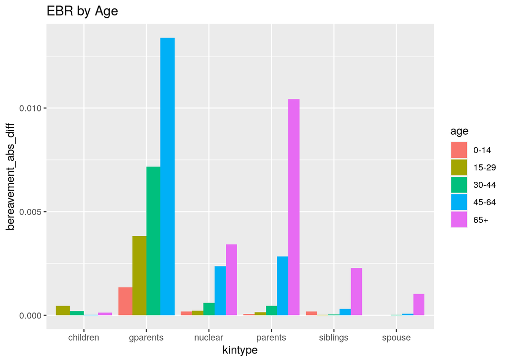

```r
#Visualize the distribution of kin
kin_probs %>%
  ungroup() %>%
  group_by(kintype, age) %>%
  summarize(n_withkin = mean(n_withkin, na.rm = T),
            n_losekin = mean(n_losekin, na.rm = T),
            pc_withkin = mean(pc_withkin, na.rm = T),
            n_total = mean(n_total, na.rm = T),
            bereavement_covid = mean(bereavement_covid, na.rm = T),
            bereavement_other = mean(bereavement_other, na.rm = T),
            bereavement_abs_diff = bereavement_covid - bereavement_other) %>%
  filter(pc_withkin > 1) %>%
  ggplot() + geom_bar(aes(x = kintype, y = bereavement_abs_diff, fill = age), position = "dodge", stat = "identity") + labs(title = "EBR by Age")
```

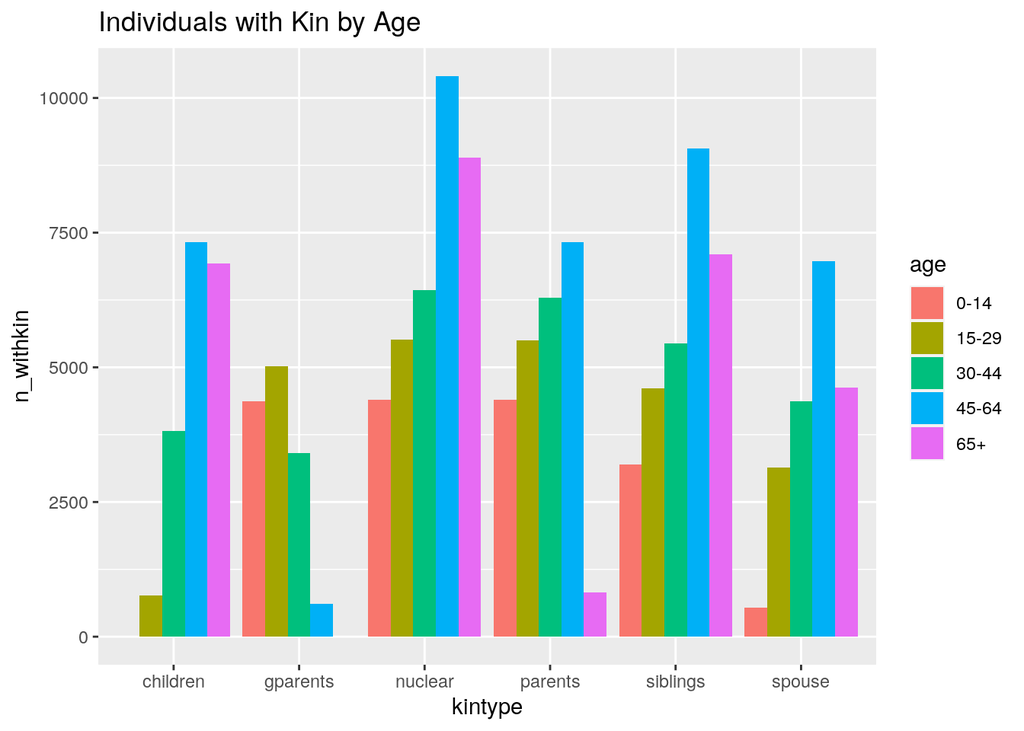

```r
#Visualize the distribution of kin
kin_probs %>%
  ungroup() %>%
  group_by(kintype, age) %>%
  summarize(n_withkin = mean(n_withkin, na.rm = T),
            n_losekin = mean(n_losekin, na.rm = T),
            pc_withkin = mean(pc_withkin, na.rm = T),
            n_total = mean(n_total, na.rm = T)) %>%
  ggplot() + geom_bar(aes(x = kintype, y = n_withkin, fill = age), position = "dodge", stat = "identity") + labs(title = "Individuals with Kin by Age")
```

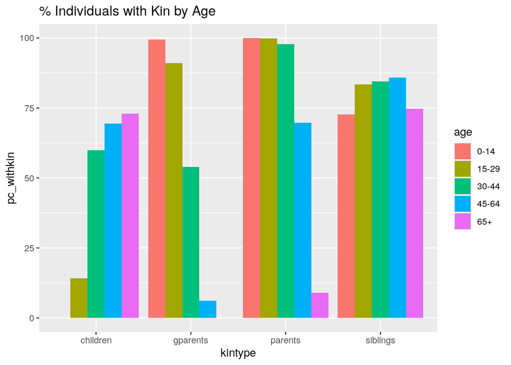

```r
#Visualize the distribution of kin
kin_probs %>%
  ungroup() %>%
  group_by(kintype, age) %>%
  summarize(n_withkin = mean(n_withkin, na.rm = T),
            n_losekin = mean(n_losekin, na.rm = T),
            pc_withkin = mean(pc_withkin, na.rm = T),
            n_total = mean(n_total, na.rm = T)) %>%
  filter(kintype %ni% c("nuclear", "spouse")) %>%
  ggplot() + geom_bar(aes(x = kintype, y = pc_withkin, fill = age), position = "dodge", stat = "identity") + labs(title = "% Individuals with Kin by Age")
```

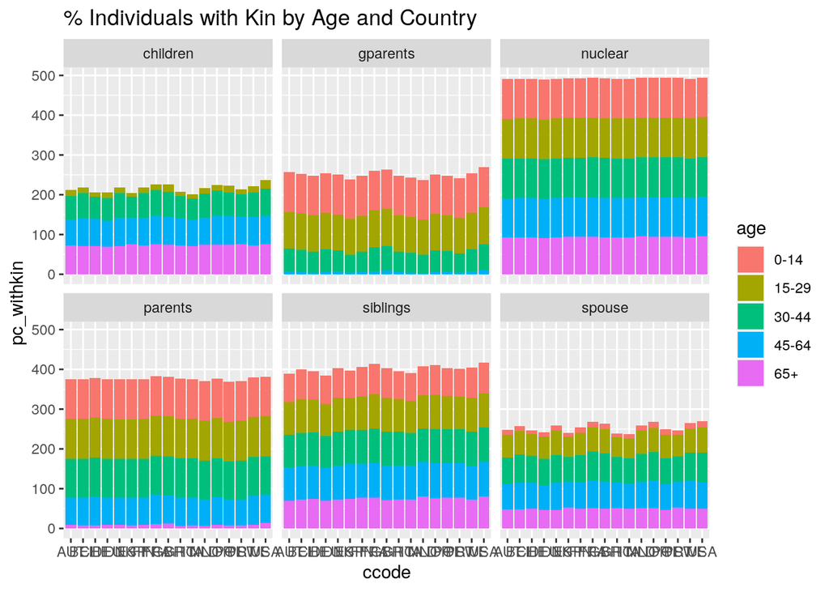

```r
#Visualize the distribution of kin by country
kin_probs %>%
  ungroup() %>%
  group_by(ccode, kintype, age) %>%
  summarize(n_withkin = mean(n_withkin, na.rm = T),
            n_losekin = mean(n_losekin, na.rm = T),
            pc_withkin = mean(pc_withkin, na.rm = T),
            n_total = mean(n_total, na.rm = T)) %>%
  #filter(kintype == "gparents") %>%
  ggplot() + geom_bar(aes(x = ccode, y = pc_withkin, fill = age), position = "stack", stat = "identity") + labs(title = "% Individuals with Kin by Age and Country") + facet_wrap(~kintype)
```

```r
prob_loss_age <- kin_probs %>%
  ungroup() %>%
  filter(pc_withkin > 1) %>%
  group_by(kintype, sex, age) %>%
  summarize(n_withkin_covid = mean(n_withkin_covid, na.rm = T),
            n_withkin_other = mean(n_withkin_other, na.rm = T),
            n_losekin_covid = mean(n_losekin_covid, na.rm = T),
            n_losekin_other = mean(n_losekin_other, na.rm = T),
            pc_withkin = mean(pc_withkin, na.rm = T)) %>%
  mutate(probloss_covid = 100*(n_losekin_covid/n_withkin_covid),
         probloss_other = 100*(n_losekin_other/n_withkin_other),
         probloss_rel_diff = 100*(probloss_covid - probloss_other)/probloss_other,
         probloss_abs_diff = probloss_covid - probloss_other)
```

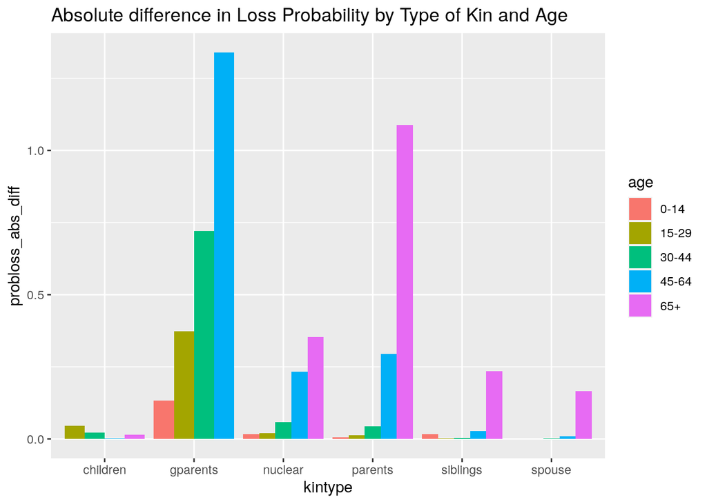

```r
prob_loss_age %>%
  ggplot() + geom_bar(aes(x = kintype, y = probloss_abs_diff, fill = age), position = "dodge", stat = "identity") + labs(title = "Absolute difference in Loss Probability by Type of Kin and Age")
```

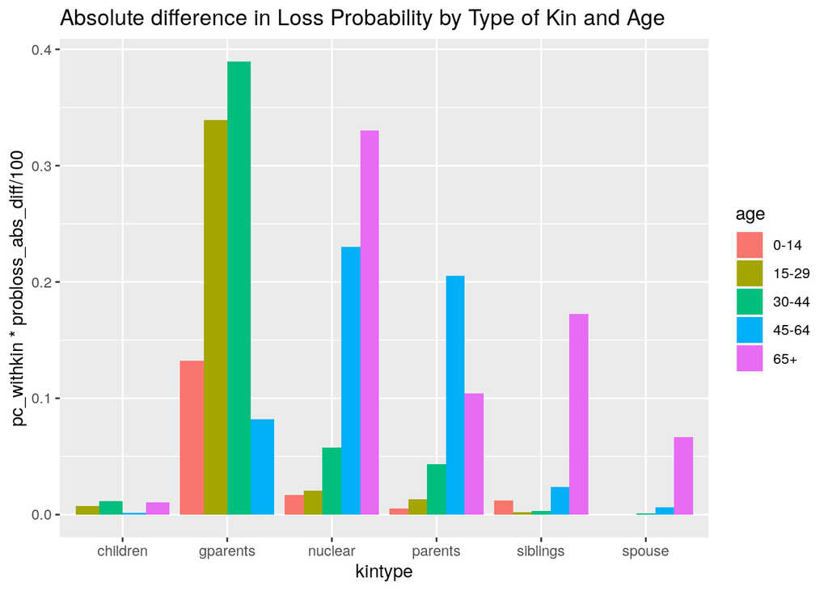

```r
prob_loss_age %>%
  ggplot() + geom_bar(aes(x = kintype, y = pc_withkin*probloss_abs_diff/100, fill = age), position = "dodge", stat = "identity") + labs(title = "Absolute difference in Loss Probability by Type of Kin and Age")
```

```r
prob_loss_age <- kin_probs %>%
  ungroup() %>%
  filter(pc_withkin > 1) %>%
  group_by(kintype, age) %>%
  summarize(n_withkin_covid = mean(n_withkin_covid, na.rm = T),
            n_withkin_other = mean(n_withkin_other, na.rm = T),
            n_losekin_covid = mean(n_losekin_covid, na.rm = T),
            n_losekin_other = mean(n_losekin_other, na.rm = T),
            pc_withkin = mean(pc_withkin, na.rm = T)) %>%
  mutate(probloss_covid = 100*(n_losekin_covid/n_withkin_covid),
         probloss_other = 100*(n_losekin_other/n_withkin_other),
         probloss_rel_diff = 100*(probloss_covid - probloss_other)/probloss_other,
         probloss_abs_diff = probloss_covid - probloss_other)
```

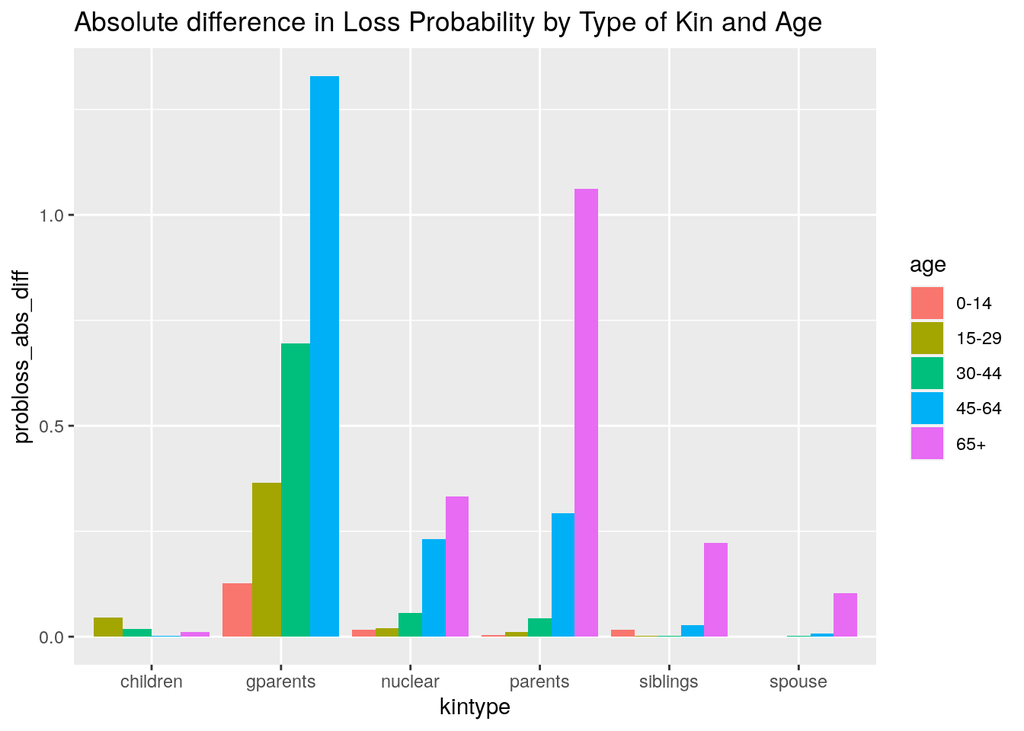

```r
prob_loss_age %>%
  ggplot() + geom_bar(aes(x = kintype, y = probloss_abs_diff, fill = age), position = "dodge", stat = "identity") + labs(title = "Absolute difference in Loss Probability by Type of Kin and Age")
```

```r
#By country
prob_loss_country <- kin_probs %>%
  ungroup() %>%
  filter(pc_withkin > 1) %>%
  group_by(ccode, country, kintype, age) %>%
  summarize(n_withkin_covid = mean(n_withkin_covid, na.rm = T),
            n_withkin_other = mean(n_withkin_other, na.rm = T),
            n_losekin_covid = mean(n_losekin_covid, na.rm = T),
            n_losekin_other = mean(n_losekin_other, na.rm = T),
            pc_withkin = mean(pc_withkin, na.rm = T)) %>%
  mutate(probloss_covid = 100*(n_losekin_covid/n_withkin_covid),
         probloss_other = 100*(n_losekin_other/n_withkin_other),
         probloss_rel_diff = 100*(probloss_covid - probloss_other)/probloss_other,
         probloss_abs_diff = probloss_covid - probloss_other)
```

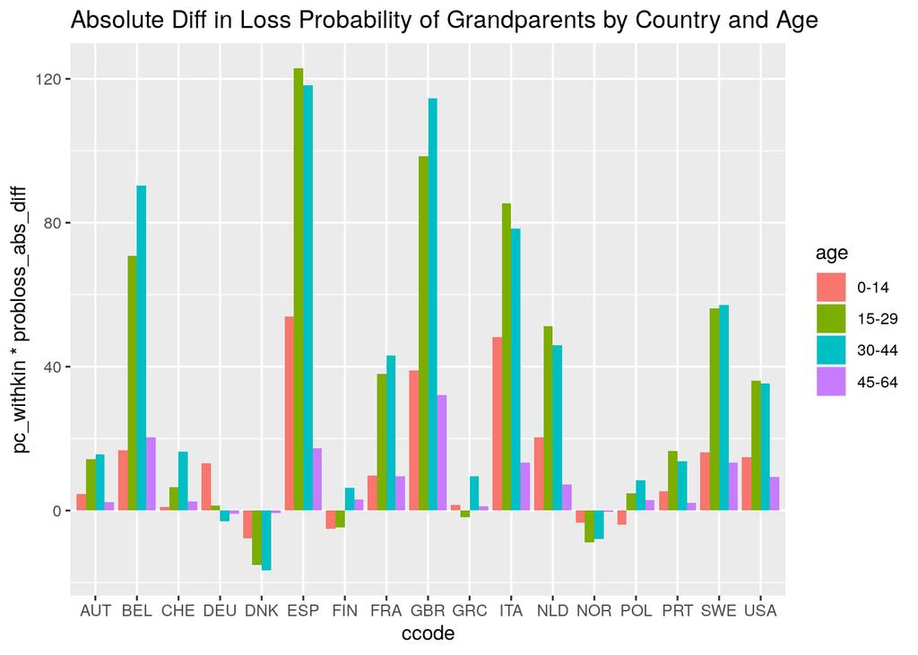

```r
prob_loss_country %>%
  filter(kintype == "gparents") %>%
  ggplot() + geom_bar(aes(x = ccode, y = pc_withkin*probloss_abs_diff, fill = age), position = "dodge", stat = "identity") + labs(title = "Absolute Diff in Loss Probability of Grandparents by Country and Age")
```

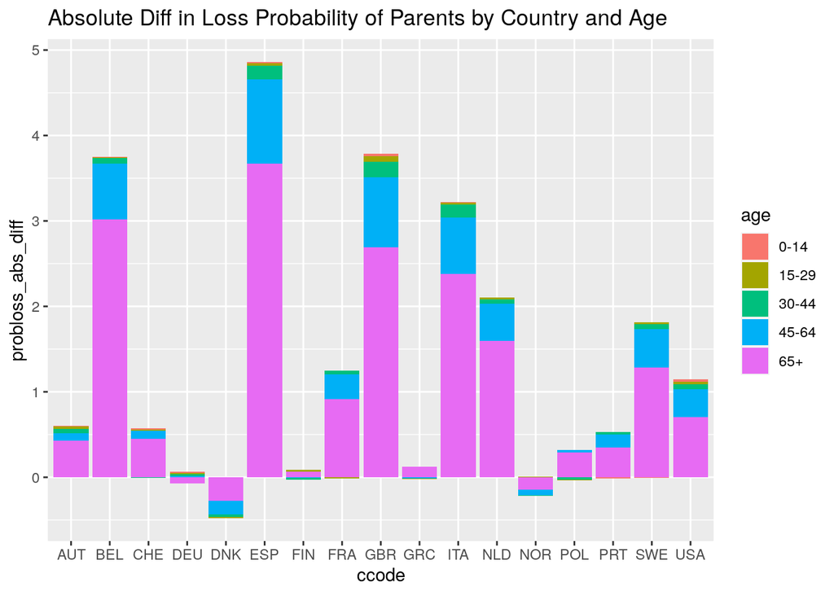

```r
prob_loss_country %>%
  filter(kintype == "parents") %>%
  ggplot() + geom_bar(aes(x = ccode, y = probloss_abs_diff, fill = age), position = "stack", stat = "identity") + labs(title = "Absolute Diff in Loss Probability of Parents by Country and Age")
```

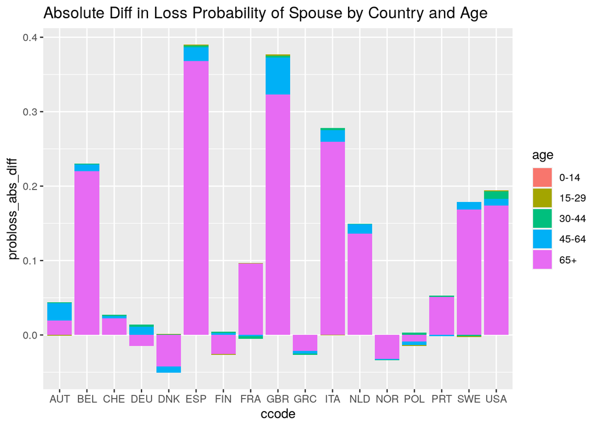

```r
prob_loss_country %>%
  filter(kintype == "spouse") %>%
  ggplot() + geom_bar(aes(x = ccode, y = probloss_abs_diff, fill = age), position = "stack", stat = "identity") + labs(title = "Absolute Diff in Loss Probability of Spouse by Country and Age")
```

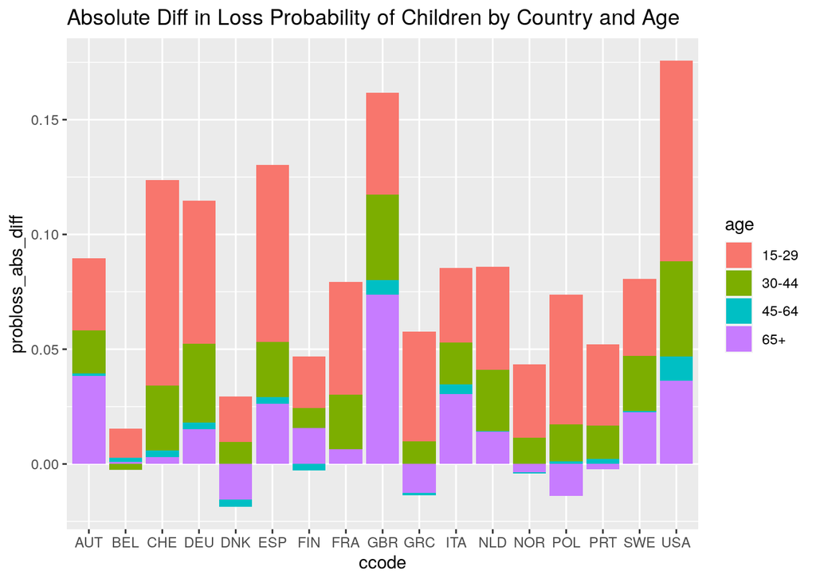

```r
prob_loss_country %>%
  filter(kintype == "children") %>%
  ggplot() + geom_bar(aes(x = ccode, y = probloss_abs_diff, fill = age), position = "stack", stat = "identity") + labs(title = "Absolute Diff in Loss Probability of Children by Country and Age")
```

## Plots for Presentation

Distribution of kin

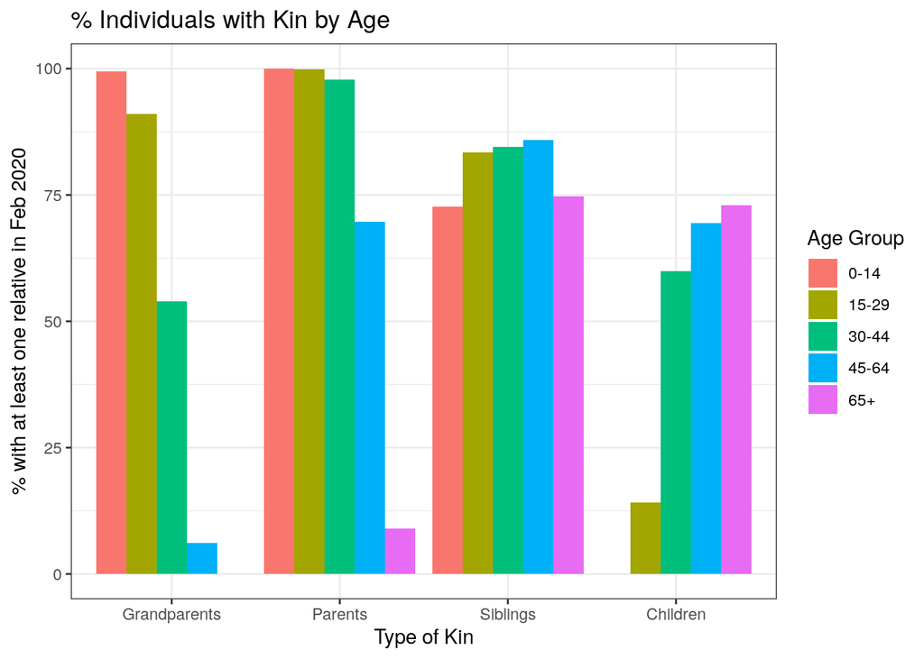

```r
#Visualize the distribution of kin
kin_probs %>%
  ungroup() %>%
  group_by(kintype, age) %>%
  summarize(n_withkin = mean(n_withkin, na.rm = T),
            n_losekin = mean(n_losekin, na.rm = T),
            pc_withkin = mean(pc_withkin, na.rm = T),
            n_total = mean(n_total, na.rm = T)) %>%
  filter(kintype %ni% c("nuclear", "spouse")) %>%
  ungroup() %>%
  mutate(kintype = str_to_title(if_else(kintype == "gparents", "grandparents", kintype)),
         kintype = ordered(kintype, levels = c("Grandparents", "Parents", "Siblings", "Children"))) %>%
  ggplot() + geom_bar(aes(x = kintype, y = pc_withkin, fill = age), position = "dodge", stat = "identity") + labs(x = "Type of Kin", y = "% with at least one relative in Feb 2020", title = "% Individuals with Kin by Age", fill = "Age Group") +
  theme_bw()
```

Probability of Loss

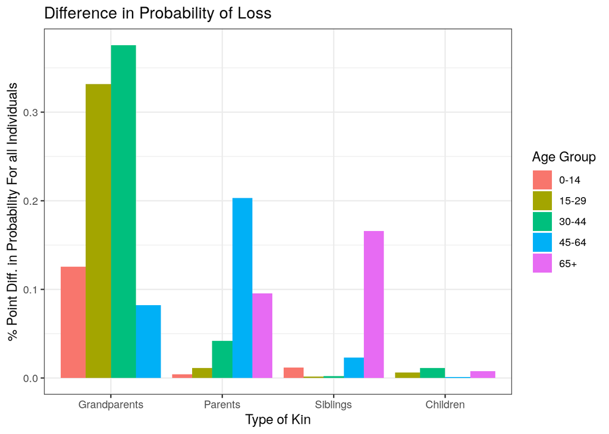

```r
prob_loss_age %>%
    filter(kintype %ni% c("nuclear", "spouse")) %>%
  ungroup() %>%
  mutate(kintype = str_to_title(if_else(kintype == "gparents", "grandparents", kintype)),
         kintype = ordered(kintype, levels = c("Grandparents", "Parents", "Siblings", "Children"))) %>%
  ggplot() + geom_bar(aes(x = kintype, y = pc_withkin*probloss_abs_diff/100, fill = age), position = "dodge", stat = "identity") + labs(title = "Difference in Probability of Loss", y = "% Point Diff. in Probability For all Individuals", x = "Type of Kin", fill = "Age Group") + theme_bw()
```

Expected Excess Bereavement

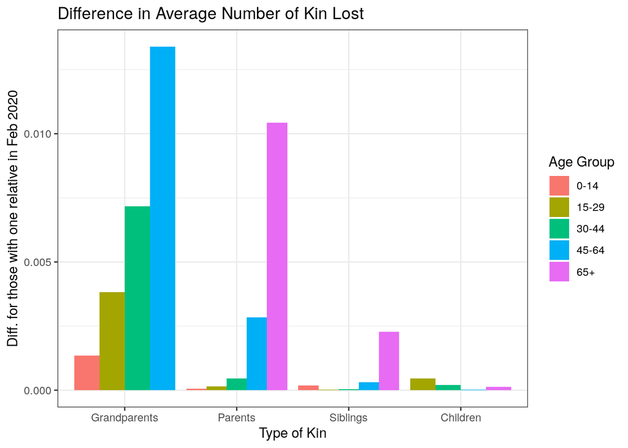

```r
#Visualize the difference in expected kin
kin_probs %>%
  ungroup() %>%
  group_by(kintype, age) %>%
  summarize(n_withkin = mean(n_withkin, na.rm = T),
            n_losekin = mean(n_losekin, na.rm = T),
            pc_withkin = mean(pc_withkin, na.rm = T),
            n_total = mean(n_total, na.rm = T),
            bereavement_covid = mean(bereavement_covid, na.rm = T),
            bereavement_other = mean(bereavement_other, na.rm = T),
            bereavement_abs_diff = bereavement_covid - bereavement_other) %>%
  filter(kintype %ni% c("nuclear", "spouse")) %>%
  ungroup() %>%
  mutate(kintype = str_to_title(if_else(kintype == "gparents", "grandparents", kintype)),
         kintype = ordered(kintype, levels = c("Grandparents", "Parents", "Siblings", "Children"))) %>%
  filter(pc_withkin > 1) %>%
  ggplot() + geom_bar(aes(x = kintype, y = bereavement_abs_diff, fill = age), position = "dodge", stat = "identity") + labs(title = "Difference in Average Number of Kin Lost", y = "Diff. for those with one relative in Feb 2020", x = "Type of Kin", fill = "Age Group") +
  theme_bw()
```

Country Level

```r
em_country <- em_level %>%
  group_by(country, ccode) %>%
  summarize(em_level = mean(em_level, na.rm = T))

prob_loss_country_sum <- kin_probs %>%
  ungroup() %>%
  filter(pc_withkin > 1) %>%
  group_by(ccode, country, kintype) %>%
  summarize(n_withkin_covid = mean(n_withkin_covid, na.rm = T),
            n_withkin_other = mean(n_withkin_other, na.rm = T),
            n_losekin_covid = mean(n_losekin_covid, na.rm = T),
            n_losekin_other = mean(n_losekin_other, na.rm = T),
            pc_withkin = mean(pc_withkin, na.rm = T),
            bereavement_covid = mean(bereavement_covid, na.rm = T),
            bereavement_other = mean(bereavement_other, na.rm = T),
            bereavement_abs_diff = bereavement_covid - bereavement_other) %>%
  mutate(probloss_covid = 100*(n_losekin_covid/n_withkin_covid),
         probloss_other = 100*(n_losekin_other/n_withkin_other),
         probloss_rel_diff = 100*(probloss_covid - probloss_other)/probloss_other,
         probloss_abs_diff = probloss_covid - probloss_other)

pop_ageratio_country <- pop_ageratio %>%
  ungroup() %>%
  group_by(country) %>%
  summarize(pop_ageratio = mean(pop_ageratio, na.rm = T))


figuredata <- merge(pop_ageratio_country, merge(em_country, prob_loss_country_sum))
```

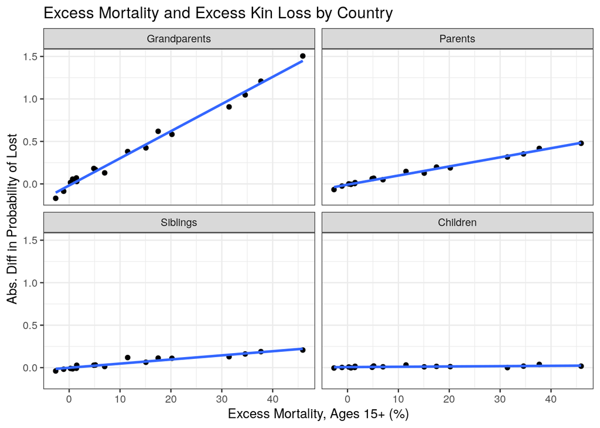

```r
figuredata %>%
  filter(kintype %ni% c("nuclear", "spouse")) %>%
  ungroup() %>%
  mutate(kintype = str_to_title(if_else(kintype == "gparents", "grandparents", kintype)),
         kintype = ordered(kintype, levels = c("Grandparents", "Parents", "Siblings", "Children"))) %>%
  ggplot(aes(x = em_level, y = probloss_abs_diff)) + geom_point() + geom_smooth(method = "lm", se = F) + facet_wrap(~kintype) +
  labs(title = "Excess Mortality and Excess Kin Loss by Country", y = "Abs. Diff in Probability of Lost", x = "Excess Mortality, Ages 15+ (%)") + theme_bw()
```